# Introduction to the New Module of Multimodal Travel (VETravelDemand)

## VisionEval Review Team Meeting #2

### Liming Wang

### August 3rd, 2017

# Outline

- Why the new module?
- Travel outcomes considered
- Model structure
- Data for model estimation
- Model specification

# Why the new module?

> A deeper understanding of how mode choices and mode share may be impacted by policy and investment decisions

> Research the key drivers of multi-modal analysis, as they relate to individual households, annual household travel, household budgets and price sensitivity.  The research will explore travel survey (household and transit) and consumer expenditure data.  The general research findings will support planning questions on these topics, and will bolster ODOT, region, and local analysis capabilities specifically by implementing a module that can be plugged into existing tools (RSPM)

# RSPM Design

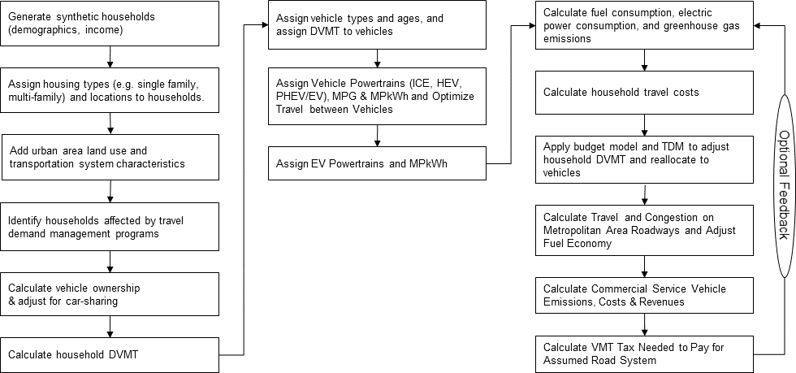

# Objectives

- Development models for multimodal travel: Driving, Transit, Bike, Walk
- At a minimum, update RSPM household VMT module with latest data
- Implement the new models for RSPM (original plan)

# Travel outcome considered

- Household VMT
    - Daily VMT
    - Annual average daily VMT
- PMT for Transit, Bike, and Walk (PMT model)
- Trip frequency and average trip length for Transit, Bike, and Walk (TFL model)

# Model structure

- 2-step models:
    1. binomial logistic regression of zero VMT/PMT
    2. power-transformed/semi-log regression model of non-zero VMT/PMT
- hurdle model and zero-inflated negative binomial:
    - Transit, Bike, and Walk trip frequency
- Tobit model
    - VMT/PMT, average trip length

# Data for model estimation

- 2009 National Household Travel Survey (NHTS) with confidential residence block group information
- EPA Smart Location Database: nationwide built environment/urban form at the block group level
- HMPS: UZA-level roadway characteristics
- NTD: UZA-level transit supply

# Variables - 1

- [Variable "cheatsheet" (credit Tara Weidner)](https://cities-lab.github.io/SPR788/RSPM-TFLmodelVariables_May2017.pdf)
- Household social-economic status:
    - HHSize, life cycle, #workers, income, drivers, vehicles per driver, # children, # retirees, dwelling type
- Regionwide variables:
    - Transportation system supply: freeway lane miles per capita, arterial lane miles per capita, transit revenue miles per capita
    - Size (area, population, employment), density

# Variables - 2

- 5D built environment measures (home location):
    - Density: du/acre (D1A), population/acre (D1B), employment/acre (D1C), activity (pop+emp)/acre (D1D)
    - Diversity: Emp & HH entropy (D2A_EPHHM)
    - Design: Lane mile ped‐oriented density/sqmi (D3apo), Intersection density‐4+ leg multi‐modal/sqmi (D3bmm4), Intersection density‐4+ leg ped‐oriented/sqmi (D3bpo4)
    - Transit: %CBG employment within 1⁄2 mile of fixed‐ guideway transit stop (D4b050), PM Peak transit svc hrly freq within 1/4 mile of block group boundary (D4c)
    - Accessibility: Emp within 45 minutes auto (D5ar), Ratio Emp Auto Accessibility vs Total MSA (D5cr), Harmonic mean of Emp within 2 miles and Pop within 5 miles (ACCESS), Emp within 5 mile of blockgroup centroid (EMPTOT_5)